# Analysis of Teaching Methods Using ANOVA

TURRI Valentín

2025-06-03

## *Problem Context*

An educational researcher wants to evaluate the effectiveness of three different methods for teaching mathematical problem-solving. Eighteen students with similar characteristics were randomly selected and randomly assigned to one of the three methods (6 students per group). After 4 weeks of instruction, a standardized test was administered. The obtained scores were:

```r
# Read CSV file
ruta <- "C:/Users/valen/OneDrive/Escritorio/Maestría en Ciencia de Datos/AID/TP5/datos.csv"

estudiantes_stats <- read_csv(ruta, locale = locale(encoding = "UTF-8"))
estudiantes_stats
```

```
## # A tibble: 6 × 3
##   tradicional colaborativo tecnologico
##         <dbl>        <dbl>       <dbl>
## 1          74           82          78
## 2          71           85          81
## 3          76           83          79
## 4          73           87          82
## 5          72           84          80
## 6          75           86          83
```

## *1. Exploratory Analysis*

*A) Compute for each method: Mean, Median, and Standard Deviation*

```r
estudiantes_stats %>%
  pivot_longer(cols = everything(),
               names_to = "metodo",
               values_to = "puntaje") %>%
  group_by(metodo) %>%
  summarise(
    mean = mean(puntaje, na.rm = TRUE),
    median = median(puntaje, na.rm = TRUE),
    std_dev = sd(puntaje, na.rm = TRUE)
  )
```

```
## # A tibble: 3 × 4
##   metodo        mean median std_dev
##   <chr>        <dbl>  <dbl>   <dbl>
## 1 colaborativo  84.5   84.5    1.87
## 2 tecnologico   80.5   80.5    1.87
## 3 tradicional   73.5   73.5    1.87
```

*B) Build a comparative boxplot for the three methods*

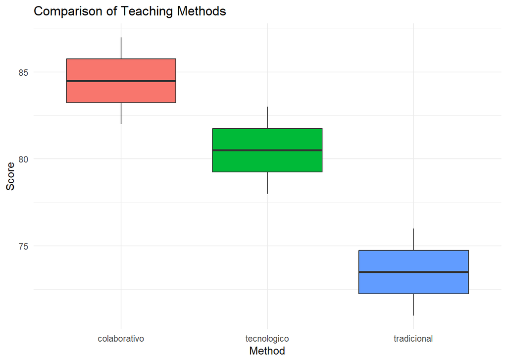

```r
estudiantes_stats %>%
  pivot_longer(cols = everything(),
               names_to = "metodo",
               values_to = "puntaje") %>%
  ggplot(aes(x = metodo, y = puntaje, fill = metodo)) +
  geom_boxplot() +
  labs(title = "Comparison of Teaching Methods",
       x = "Method",
       y = "Score") +
  theme_minimal() +
  theme(legend.position = "none")
```

*C) Based on the descriptive statistics and the boxplot, formulate a preliminary hypothesis about which method might be more effective*

More rigorously, the collaborative method has the highest average score, followed by the technological method, and finally the traditional method.

In all cases, the standard deviation is approximately 2 points, indicating that the scores are highly concentrated around the mean.

## *2. Assumption Verification*

ANOVA requires three fundamental assumptions, which are verified below.

### A) *Independence*

The experimental design guarantees independence of observations for the following reasons:

- **Random assignment:** Students were randomly assigned to the three teaching methods.
- **Separate groups:** Each student participated in only one method.
- **Individual assessment:** The standardized test was taken individually after instruction.

### B) *Normality*

Normality is evaluated using the Shapiro-Wilk test.

```r
datos_long <- estudiantes_stats %>%
  pivot_longer(cols = everything(), names_to = "metodo", values_to = "puntaje")

by(datos_long$puntaje, datos_long$metodo, shapiro.test)
```

```
## datos_long$metodo: colaborativo
##
##  Shapiro-Wilk normality test
##
## data:  dd[x, ]
## W = 0.98189, p-value = 0.9606
##
## ------------------------------------------------------------
## datos_long$metodo: tecnologico
##
##  Shapiro-Wilk normality test
##
## data:  dd[x, ]
## W = 0.98189, p-value = 0.9606
##
## ------------------------------------------------------------
## datos_long$metodo: tradicional
##
##  Shapiro-Wilk normality test
##
## data:  dd[x, ]
## W = 0.98189, p-value = 0.9606
```

Since all p-values are greater than 0.05, normality is not rejected for any group.

```r
modelo_anova <- aov(puntaje ~ metodo, data = datos_long)
residuos <- residuals(modelo_anova)
shapiro.test(residuos)
```

```
##
##  Shapiro-Wilk normality test
##
## data:  residuos
## W = 0.9169, p-value = 0.1139
```

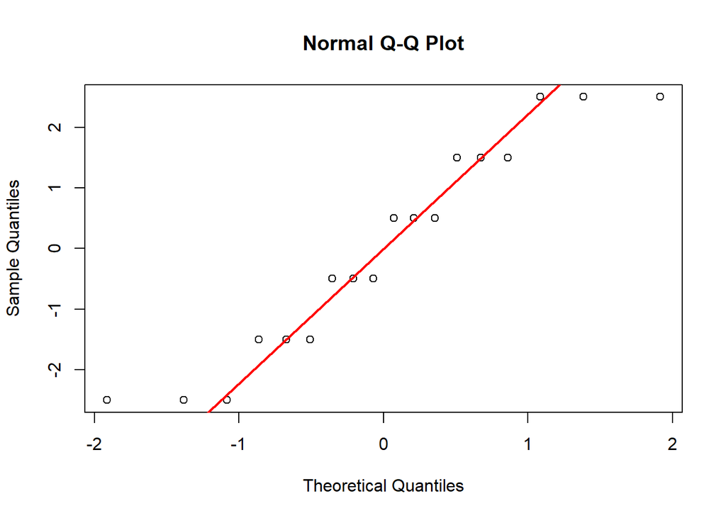

```r
qqnorm(residuos)
qqline(residuos, col = "red", lwd = 2)
```

The Q-Q plot shows that residuals closely follow the normal distribution.

### C) *Homoscedasticity*

```r
leveneTest(puntaje ~ metodo, data = datos_long)
```

```
## Levene's Test for Homogeneity of Variance (center = median)
##       Df F value Pr(>F)
## group  2       0      1
##       15
```

The p-value equals 1, so equal variances are assumed.

## *3. Analysis of Variance*

### A) Hypotheses

$$H_0: \mu_1 = \mu_2 = \mu_3$$

$$H_1: \exists\, i, j \text{ such that } \mu_i \ne \mu_j$$

### B) Why not multiple t-tests?

Multiple t-tests increase the probability of committing a Type I error. ANOVA controls this risk by performing a single global test.

### C) Interpretation of the F statistic

The F statistic compares variability between groups to variability within groups. Large F values indicate that at least one group mean differs significantly.

### D) Decision rule

```r
summary(modelo_anova)
```

```
##             Df Sum Sq Mean Sq F value   Pr(>F)
## metodo       2  372.0   186.0   53.14 1.56e-07 ***
## Residuals   15   52.5     3.5
## ---
## Signif. codes:  0 '***' 0.001 '**' 0.01 '*' 0.05 '.' 0.1 ' ' 1
```

```r
qf(0.95, df1 = 2, df2 = 15)
```

```
## [1] 3.68232
```

Since the observed F is greater than the critical F and the p-value is below 0.05, the null hypothesis is rejected.

## *4. Post-Hoc Comparisons*

```r
tukey <- TukeyHSD(modelo_anova)
tukey
```

```
##   Tukey multiple comparisons of means
##     95% family-wise confidence level
##
## Fit: aov(formula = puntaje ~ metodo, data = datos_long)
##
## $metodo
##                          diff        lwr       upr     p adj
## tecnologico-colaborativo   -4  -6.805589 -1.194411 0.0056641
## tradicional-colaborativo  -11 -13.805589 -8.194411 0.0000001
## tradicional-tecnologico    -7  -9.805589 -4.194411 0.0000292
```

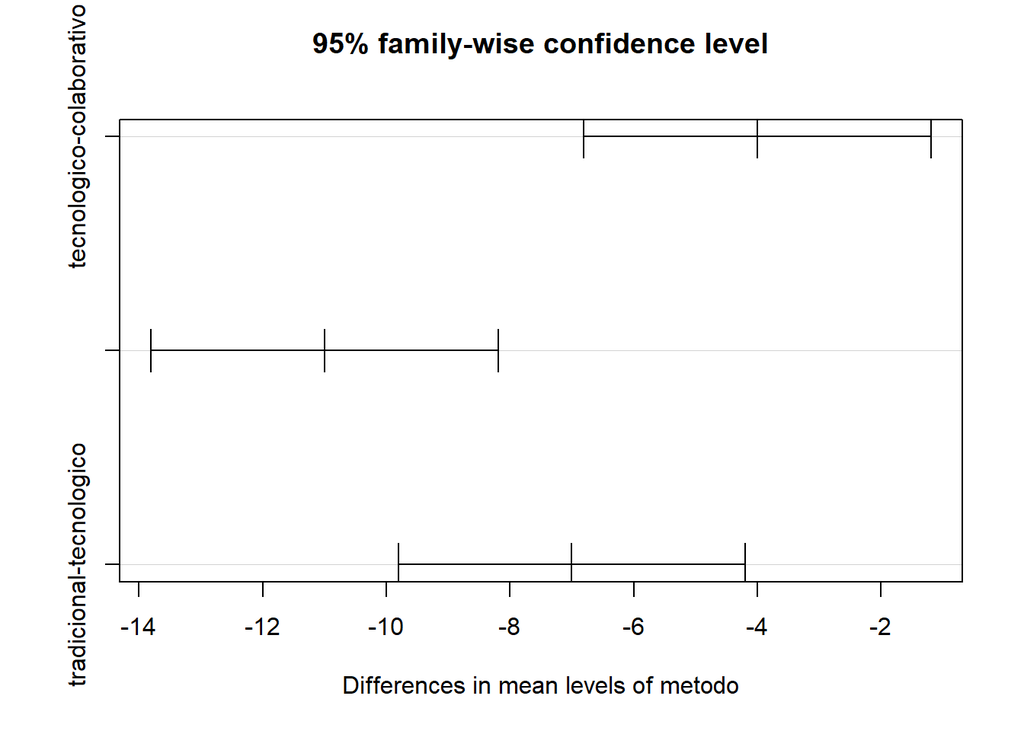

```r
plot(tukey)
```

All method pairs differ significantly.

## *5. Critical Analysis*

### Limitations

- Small sample size (18 students)
- Possible artificial data construction
- Perfectly equal standard deviations
- Extremely regular mean spacing

### Extreme outlier discussion

Robust methods (e.g., Kruskal-Wallis) may be used, or justified exclusion if measurement error is proven.